# Final Paper

Orsos Mihaly

feb. 10.

# Data analysis project bikeshare

During this paper I will perform a data analysis on bike share in Washington D.C., USA. The data set is related to two-year historical log, corresponding to years 2011 and 2012. The usage of the bike system can be influenced from many factor. For example the weather conditions: I expect in the hotter weather the total rent is going to be higher than is the winter period. The data is hourly frequency. I have 17379 rows and 17 columns. During the analysis I will build a predictive model which is going to predict how many bike is going to be rented in any hour.

## Exploratory Analysis

In this part I will check the predictors (mainly weather conditions) and describe the relationship the total rent and the examined variable. Here I can find evidence to the weather condition has influence to the usage of the total bike rent.

### Read data, quick look

```r
setwd("C:/Users/Mihály/Dropbox/Winter semester/Data Science for Business/my_code/bikeshare")
d <- read.csv("hour.csv", header = T, sep=",", stringsAsFactors = F)
dim(d)
```

```
## [1] 17379    17
```

```r
head(d)
```

```
##   instant     dteday season yr mnth hr holiday weekday workingday
## 1       1 2011-01-01      1  0    1  0       0       6          0
## 2       2 2011-01-01      1  0    1  1       0       6          0
## 3       3 2011-01-01      1  0    1  2       0       6          0
## 4       4 2011-01-01      1  0    1  3       0       6          0
## 5       5 2011-01-01      1  0    1  4       0       6          0
## 6       6 2011-01-01      1  0    1  5       0       6          0
##   weathersit temp  atemp  hum windspeed casual registered cnt
## 1          1 0.24 0.2879 0.81    0.0000      3         13  16
## 2          1 0.22 0.2727 0.80    0.0000      8         32  40
## 3          1 0.22 0.2727 0.80    0.0000      5         27  32
## 4          1 0.24 0.2879 0.75    0.0000      3         10  13
## 5          1 0.24 0.2879 0.75    0.0000      0          1   1
## 6          2 0.24 0.2576 0.75    0.0896      0          1   1
```

```r
str(d)
```

```
## 'data.frame':    17379 obs. of  17 variables:
##  $ instant   : int  1 2 3 4 5 6 7 8 9 10 ...
##  $ dteday    : chr  "2011-01-01" "2011-01-01" "2011-01-01" "2011-01-01" ...
##  $ season    : int  1 1 1 1 1 1 1 1 1 1 ...
##  $ yr        : int  0 0 0 0 0 0 0 0 0 0 ...
##  $ mnth      : int  1 1 1 1 1 1 1 1 1 1 ...
##  $ hr        : int  0 1 2 3 4 5 6 7 8 9 ...
##  $ holiday   : int  0 0 0 0 0 0 0 0 0 0 ...
##  $ weekday   : int  6 6 6 6 6 6 6 6 6 6 ...
##  $ workingday: int  0 0 0 0 0 0 0 0 0 0 ...
##  $ weathersit: int  1 1 1 1 1 2 1 1 1 1 ...
##  $ temp      : num  0.24 0.22 0.22 0.24 0.24 0.24 0.22 0.2 0.24 0.32 ...
##  $ atemp     : num  0.288 0.273 0.273 0.288 0.288 ...
##  $ hum       : num  0.81 0.8 0.8 0.75 0.75 0.75 0.8 0.86 0.75 0.76 ...
##  $ windspeed : num  0 0 0 0 0 0.0896 0 0 0 0 ...
##  $ casual    : int  3 8 5 3 0 0 2 1 1 8 ...
##  $ registered: int  13 32 27 10 1 1 0 2 7 6 ...
##  $ cnt       : int  16 40 32 13 1 1 2 3 8 14 ...
```

```r
colnames(d)
```

```
##  [1] "instant"    "dteday"     "season"     "yr"         "mnth"
##  [6] "hr"         "holiday"    "weekday"    "workingday" "weathersit"
## [11] "temp"       "atemp"      "hum"        "windspeed"  "casual"
## [16] "registered" "cnt"
```

```r
summary(d)
```

```
##     instant         dteday              season            yr
##  Min.   :    1   Length:17379       Min.   :1.000   Min.   :0.0000
##  1st Qu.: 4346   Class :character   1st Qu.:2.000   1st Qu.:0.0000
##  Median : 8690   Mode  :character   Median :3.000   Median :1.0000
##  Mean   : 8690                      Mean   :2.502   Mean   :0.5026
##  3rd Qu.:13034                      3rd Qu.:3.000   3rd Qu.:1.0000
##  Max.   :17379                      Max.   :4.000   Max.   :1.0000
##       mnth              hr           holiday           weekday
##  Min.   : 1.000   Min.   : 0.00   Min.   :0.00000   Min.   :0.000
##  1st Qu.: 4.000   1st Qu.: 6.00   1st Qu.:0.00000   1st Qu.:1.000
##  Median : 7.000   Median :12.00   Median :0.00000   Median :3.000
##  Mean   : 6.538   Mean   :11.55   Mean   :0.02877   Mean   :3.004
##  3rd Qu.:10.000   3rd Qu.:18.00   3rd Qu.:0.00000   3rd Qu.:5.000
##  Max.   :12.000   Max.   :23.00   Max.   :1.00000   Max.   :6.000
##    workingday       weathersit         temp           atemp
##  Min.   :0.0000   Min.   :1.000   Min.   :0.020   Min.   :0.0000
##  1st Qu.:0.0000   1st Qu.:1.000   1st Qu.:0.340   1st Qu.:0.3333
##  Median :1.0000   Median :1.000   Median :0.500   Median :0.4848
##  Mean   :0.6827   Mean   :1.425   Mean   :0.497   Mean   :0.4758
##  3rd Qu.:1.0000   3rd Qu.:2.000   3rd Qu.:0.660   3rd Qu.:0.6212
##  Max.   :1.0000   Max.   :4.000   Max.   :1.000   Max.   :1.0000
##       hum           windspeed          casual         registered
##  Min.   :0.0000   Min.   :0.0000   Min.   :  0.00   Min.   :  0.0
##  1st Qu.:0.4800   1st Qu.:0.1045   1st Qu.:  4.00   1st Qu.: 34.0
##  Median :0.6300   Median :0.1940   Median : 17.00   Median :115.0
##  Mean   :0.6272   Mean   :0.1901   Mean   : 35.68   Mean   :153.8
##  3rd Qu.:0.7800   3rd Qu.:0.2537   3rd Qu.: 48.00   3rd Qu.:220.0
##  Max.   :1.0000   Max.   :0.8507   Max.   :367.00   Max.   :886.0
##       cnt
##  Min.   :  1.0
##  1st Qu.: 40.0
##  Median :142.0
##  Mean   :189.5
##  3rd Qu.:281.0
##  Max.   :977.0
```

```
- instant: record index
- dteday : date
- season : season (1:springer, 2:summer, 3:fall, 4:winter)
- yr : year (0: 2011, 1:2012)
- mnth : month ( 1 to 12)
- hr : hour (0 to 23)
- holiday : weather day is holiday or not (extracted from http://dchr.dc.gov/page/holiday-schedule)
- weekday : day of the week
- workingday : if day is neither weekend nor holiday is 1, otherwise is 0.
+ weathersit :
    - 1: Clear, Few clouds, Partly cloudy, Partly cloudy
    - 2: Mist + Cloudy, Mist + Broken clouds, Mist + Few clouds, Mist
    - 3: Light Snow, Light Rain + Thunderstorm + Scattered clouds, Light Rain + Scattered clouds
    - 4: Heavy Rain + Ice Pallets + Thunderstorm + Mist, Snow + Fog
- temp : Normalized temperature in Celsius. The values are divided to 41 (max)
- atemp: Normalized feeling temperature in Celsius. The values are divided to 50 (max)
- hum: Normalized humidity. The values are divided to 100 (max)
- windspeed: Normalized wind speed. The values are divided to 67 (max)
- casual: count of casual users
- registered: count of registered users
- cnt: count of total rental bikes including both casual and registered
```

### Target variable: cnt

The number of the bikes which were used during the listted hour

```r
summary(d$cnt)
```

```
##    Min. 1st Qu.  Median    Mean 3rd Qu.    Max.
##     1.0    40.0   142.0   189.5   281.0   977.0
```

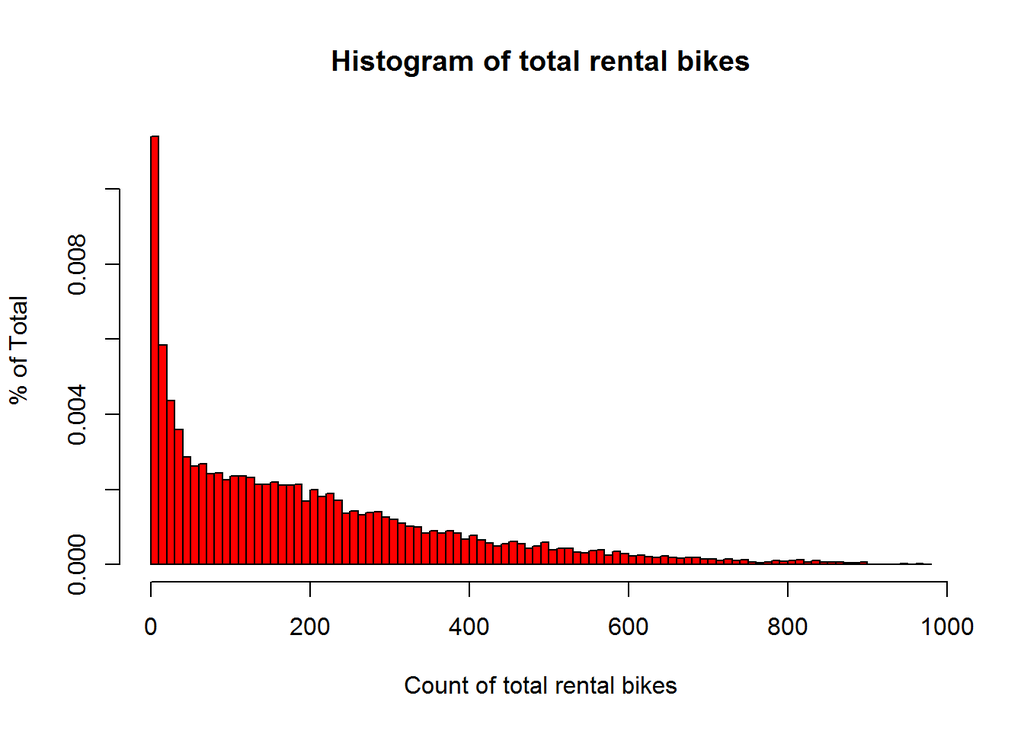

```r
hist(d$cnt, freq = F, breaks = 80, col = "red", main = "Histogram of total rental bikes", xlab = "Count of total rental bikes", ylab = "% of Total")
```

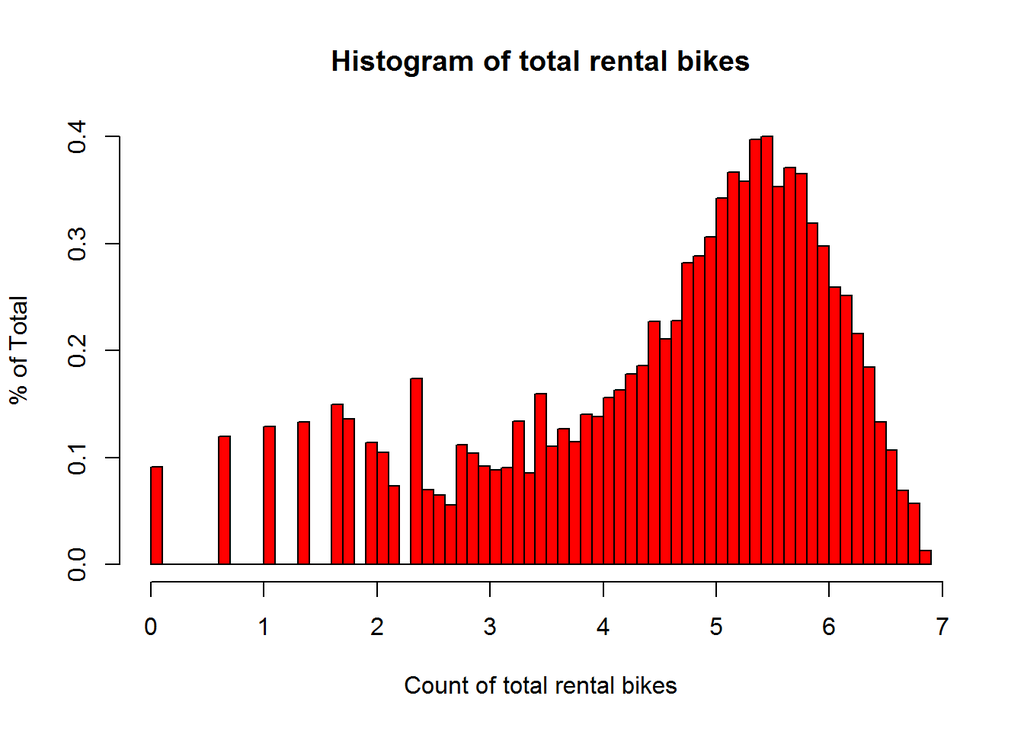

```r
hist(log(d$cnt), freq = F, breaks = 80, col = "red", main = "Histogram of total rental bikes", xlab = "Count of total rental bikes", ylab = "% of Total")
```

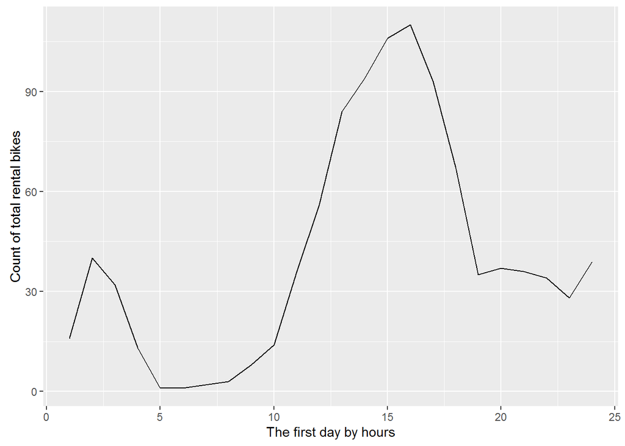

```r
d[ 1:24,] %>%
  ggplot(aes(x=instant, y = cnt))+
  geom_line()+
  xlab("The first day by hours") +
  ylab("Count of total rental bikes")
```

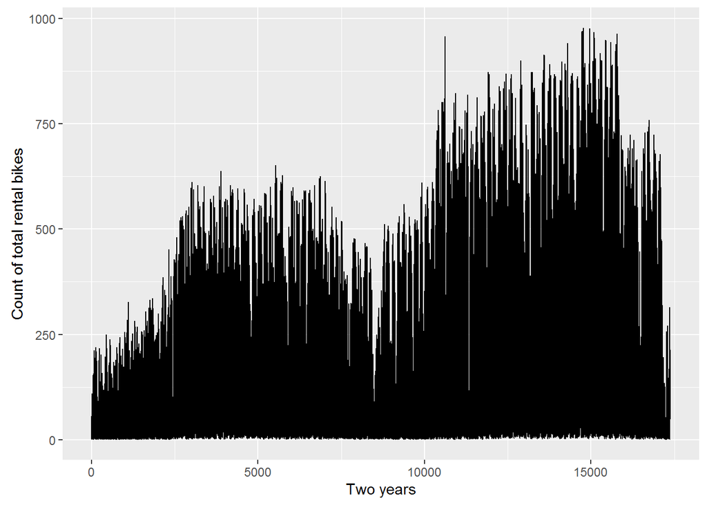

```r
d %>%
  ggplot(aes(x=instant, y = cnt))+
  geom_line()+
  xlab("Two years") +
  ylab("Count of total rental bikes")
```

### Because of the long right tail I will take log of the target variable.

```r
d$cnt <- log(d$cnt)
```

### Predictor: season

It shows the season (1:springer, 2:summer, 3:fall, 4:winter)

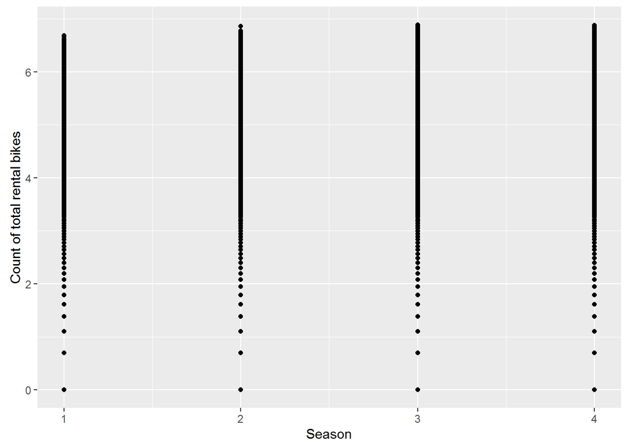

```r
d %>%
  ggplot(aes(x= season, y= cnt)) +
  geom_point()  +
  xlab("Season") +
  ylab("Count of total rental bikes")
```

```r
d1<-
d %>%
  group_by(season) %>%
  summarise(Total_rental = sum(cnt))
d1
```

```
## Source: local data frame [4 x 2]
##
##   season Total_rental
##    (int)        (dbl)
## 1      1     16779.74
## 2      2     20545.05
## 3      3     21906.13
## 4      4     19601.64
```

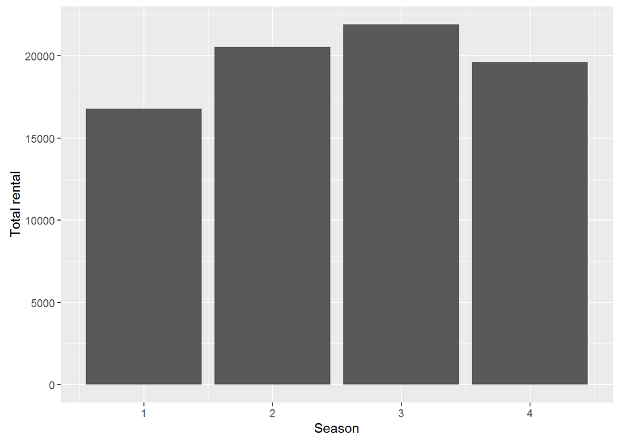

```r
d1%>%
  ggplot(aes(season, Total_rental))+geom_bar(stat = "identity")+
  xlab("Season")+
  ylab("Total rental")
```

### Predictor: mnth

month (1 to 12)

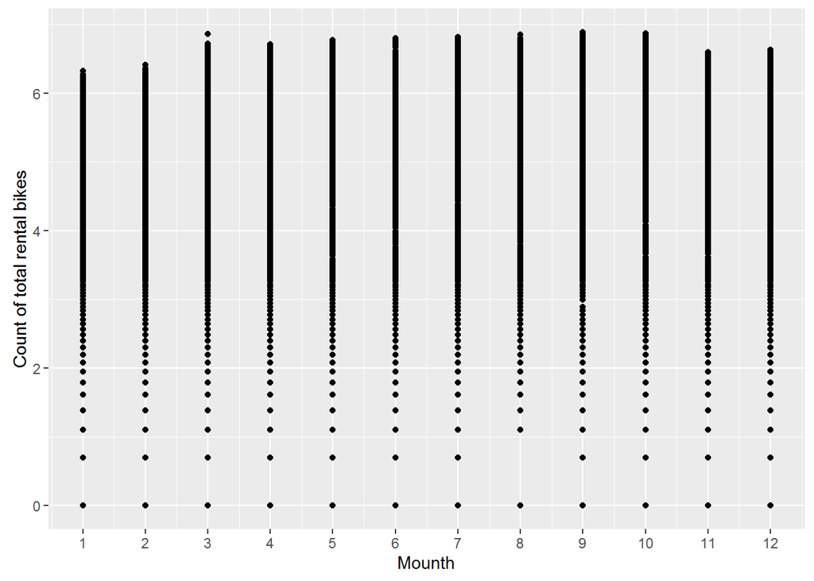

```r
d %>%
  ggplot(aes(x= mnth, y= cnt)) +
  scale_x_continuous(breaks = c(1:12))+
  geom_point()  +
  xlab("Mounth") +
  ylab("Count of total rental bikes")
```

```r
d2<-
d %>%
  group_by(mnth) %>%
  summarise(Total_rental = sum(cnt))
d2
```

```
## Source: local data frame [12 x 2]
##
##     mnth Total_rental
##    (int)        (dbl)
## 1      1     5460.145
## 2      2     5381.244
## 3      3     6262.934
## 4      4     6463.962
## 5      5     7123.018
## 6      6     7049.748
## 7      7     7273.054
## 8      8     7182.820
## 9      9     6961.091
## 10    10     6884.463
## 11    11     6501.121
## 12    12     6288.971
```

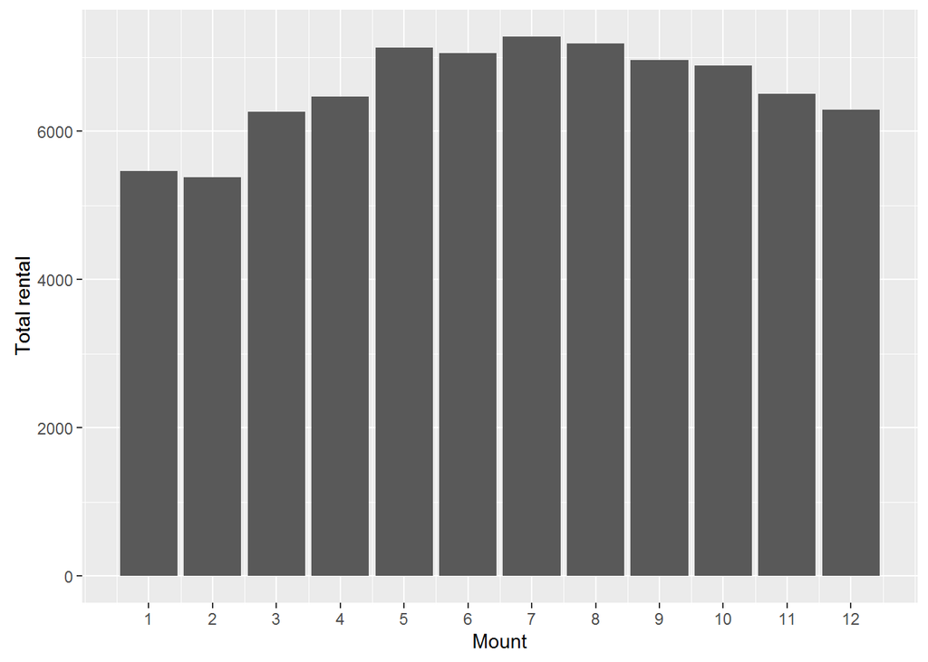

```r
d2%>%
  ggplot(aes(mnth, Total_rental))+geom_bar(stat = "identity")+
  scale_x_continuous(breaks = c(1:12))+
  xlab("Mount")+
  ylab("Total rental")
```

### Predictor: hr

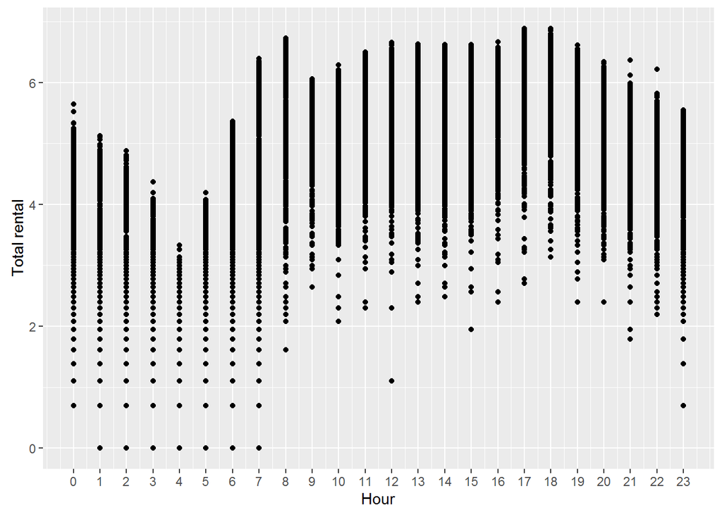

```r
d%>%
  ggplot(aes(x= hr, y= cnt))+
  scale_x_continuous(breaks= c(0:23))+
  geom_point()+
  xlab("Hour")+
  ylab("Total rental")
```

```r
d3 <-
d%>%
  group_by(hr)%>%
  summarise(Total_rental= sum(cnt))
d3
```

```
## Source: local data frame [24 x 2]
##
##       hr Total_rental
##    (int)        (dbl)
## 1      0     2676.762
## 2      1     2203.259
## 3      2     1786.754
## 4      3     1337.766
## 5      4     1122.656
## 6      5     1923.010
## 7      6     2814.583
## 8      7     3536.940
## 9      8     4025.031
## 10     9     3824.496
## ..   ...          ...
```

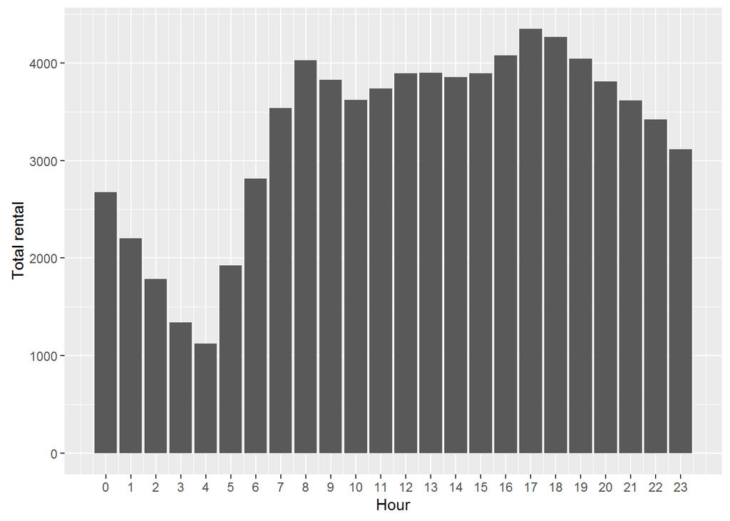

```r
d3%>%
  ggplot(aes(x=hr, y= Total_rental))+
  geom_bar(stat = "identity")+
  scale_x_continuous(breaks=c(0:23))+
  xlab("Hour")+
  ylab("Total rental")
```

### Predictor: holiday

weather day is holiday or not (extracted from http://dchr.dc.gov/page/holiday-schedule)

```r
summary(as.factor(d$holiday))
```

```
##     0     1
## 16879   500
```

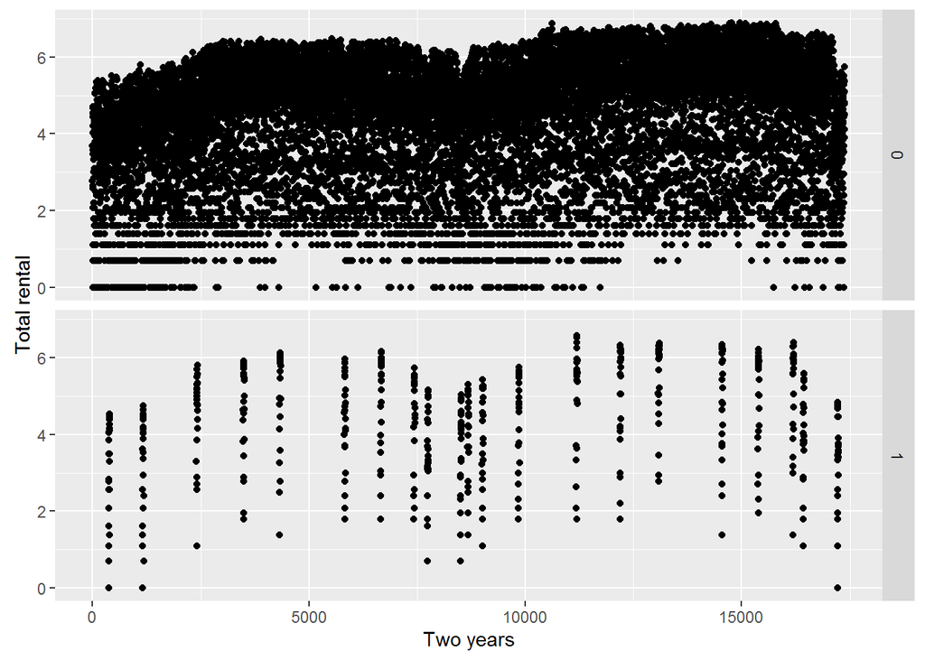

```r
d %>%
  ggplot(aes(x=instant, y= cnt))+ geom_point()+ facet_grid(holiday ~.)+
  xlab("Two years")  +
  ylab("Total rental")
```

```r
d4<-
d%>%
  group_by(holiday)%>%
  summarise(Total_rental= sum(cnt))
d4
```

```
## Source: local data frame [2 x 2]
##
##   holiday Total_rental
##     (int)        (dbl)
## 1       0    76672.180
## 2       1     2160.391
```

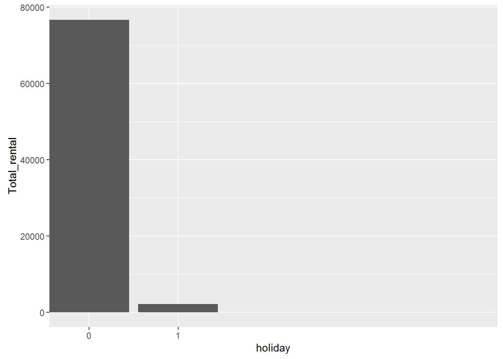

```r
d4 %>%
  ggplot(aes(x= holiday, y= Total_rental))+
  geom_bar(stat = "identity")+
  scale_x_discrete(breaks=c(0,1))
```

### Predictor: weekday

day of the week (0 to 6, Sunday:0, Monday:1, etc)

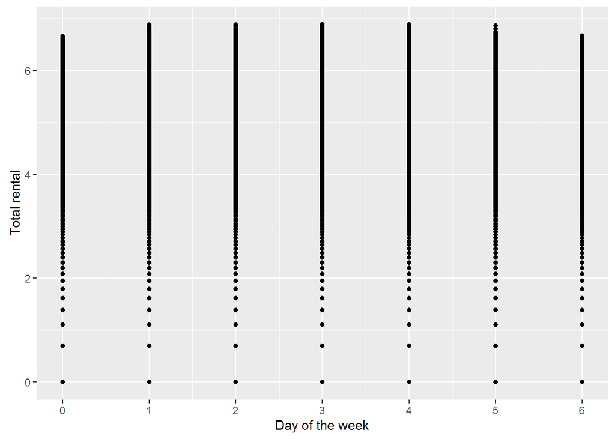

```r
d%>%
  ggplot(aes(x= weekday, y= cnt))+
  scale_x_continuous(breaks= c(0:6))+
  geom_point()+
  xlab("Day of the week")+
  ylab("Total rental")
```

```r
d5 <-
d%>%
  group_by(weekday)%>%
  summarise(Total_rental= sum(cnt))
d5
```

```
## Source: local data frame [7 x 2]
##
##   weekday Total_rental
##     (int)        (dbl)
## 1       0     11306.03
## 2       1     11081.87
## 3       2     11018.12
## 4       3     11088.85
## 5       4     11277.82
## 6       5     11531.93
## 7       6     11527.94
```

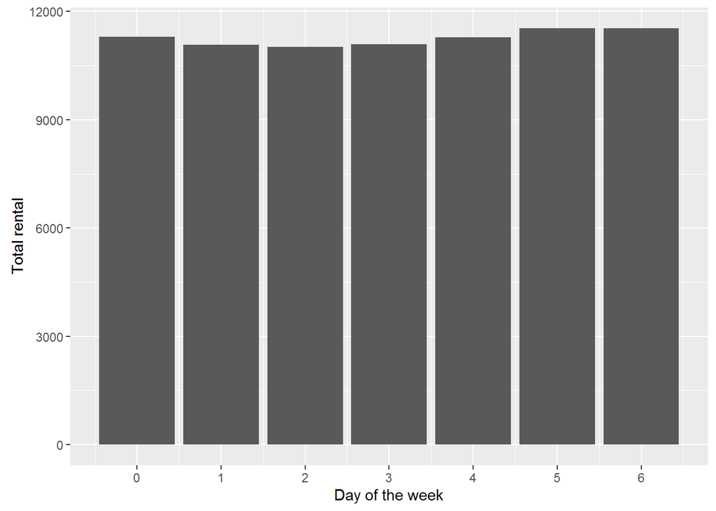

```r
d5%>%
  ggplot(aes(x=weekday, y= Total_rental))+
  geom_bar(stat = "identity")+
  scale_x_continuous(breaks=c(0:6))+
  xlab("Day of the week")+
  ylab("Total rental")
```

### Predictor: workingday

If day is neither weekend nor holiday is 1, otherwise is 0.

```r
summary(as.factor(d$workingday))
```

```
##     0     1
##  5514 11865
```

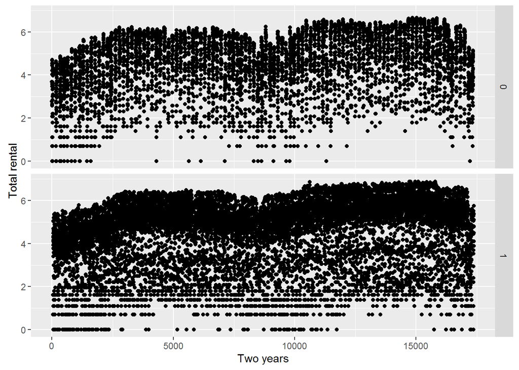

```r
d %>%
  ggplot(aes(x=instant, y= cnt))+ geom_point()+ facet_grid(workingday ~.)+
  xlab("Two years")  +
  ylab("Total rental")
```

```r
d6<-
d%>%
  group_by(workingday)%>%
  summarise(Total_rental= sum(cnt))
d6
```

```
## Source: local data frame [2 x 2]
##
##   workingday Total_rental
##        (int)        (dbl)
## 1          0     24994.37
## 2          1     53838.21
```

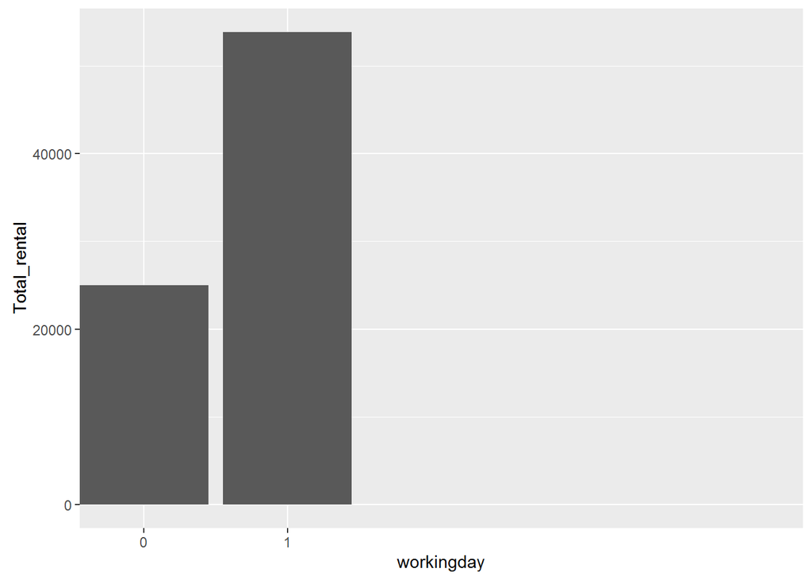

```r
d6 %>%
  ggplot(aes(x= workingday, y= Total_rental))+
  geom_bar(stat = "identity")+
  scale_x_discrete(breaks=c(0,1))
```

### Predictor: weathersit

1. Clear, Few clouds, Partly cloudy, Partly cloudy
2. Mist + Cloudy, Mist + Broken clouds, Mist + Few clouds, Mist
3. Light Snow, Light Rain + Thunderstorm + Scattered clouds, Light Rain + Scattered clouds
4. Heavy Rain + Ice Pallets + Thunderstorm + Mist, Snow + Fog

```r
summary(as.factor(d$weathersit))
```

```
##     1     2     3     4
## 11413  4544  1419     3
```

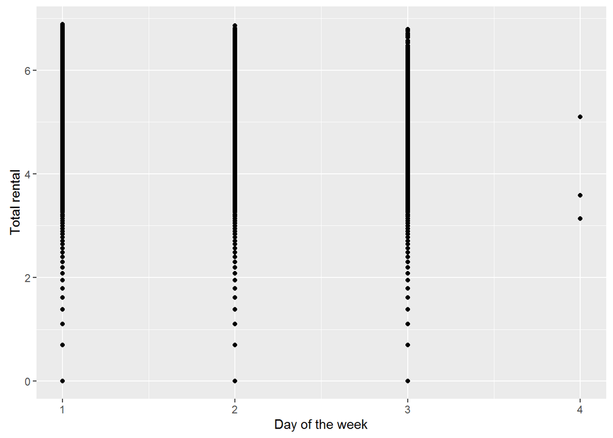

```r
d%>%
  ggplot(aes(x= weathersit, y= cnt))+
  scale_x_continuous(breaks= c(0:4))+
  geom_point()+
  xlab("Day of the week")+
  ylab("Total rental")
```

```r
d7 <-
d%>%
  group_by(weathersit)%>%
  summarise(Total_rental= sum(cnt))
d7
```

```
## Source: local data frame [4 x 2]
##
##   weathersit Total_rental
##        (int)        (dbl)
## 1          1  52868.59281
## 2          2  20392.42710
## 3          3   5559.73210
## 4          4     11.81888
```

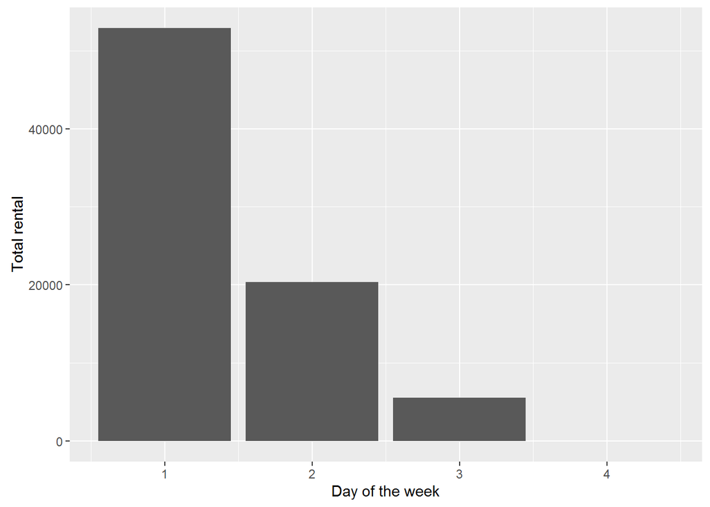

```r
d7%>%
  ggplot(aes(x=weathersit, y= Total_rental))+
  geom_bar(stat = "identity")+
  scale_x_continuous(breaks=c(0:6))+
  xlab("Day of the week")+
  ylab("Total rental")
```

### Predictor: temp

Normalized temperature in Celsius. The values are divided to 41 (max)

```r
temp_Stats <-  c(Mean = mean(d$temp),
                 Std. = sd(d$temp),
                 Min. = min(d$temp),
                 Median = median(d$temp),
                 Max. = max(d$temp),
                 Num. = length(d$temp)
)
print(temp_Stats)
```

```
##         Mean         Std.         Min.       Median         Max.
## 4.969872e-01 1.925561e-01 2.000000e-02 5.000000e-01 1.000000e+00
##         Num.
## 1.737900e+04
```

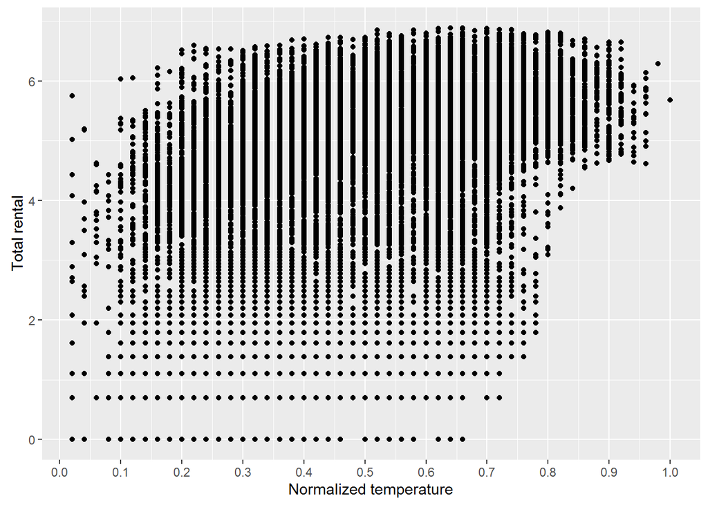

```r
d%>%
ggplot(aes(x=temp, y= cnt))+
  geom_point()+
  scale_x_continuous(breaks=c(seq(from =0, to = 1,by = 0.1) ))+
  xlab("Normalized temperature")+
  ylab("Total rental")
```

```r
d8 <-
d%>%
  group_by(temp)%>%
  summarise(Total_rental= sum(cnt))
d8
```

```
## Source: local data frame [50 x 2]
##
##     temp Total_rental
##    (dbl)        (dbl)
## 1   0.02     38.60135
## 2   0.04     38.77166
## 3   0.06     53.79935
## 4   0.08     44.16938
## 5   0.10    151.19738
## 6   0.12    240.88881
## 7   0.14    440.46575
## 8   0.16    797.41137
## 9   0.18    526.61658
## 10  0.20   1234.51097
## ..   ...          ...
```

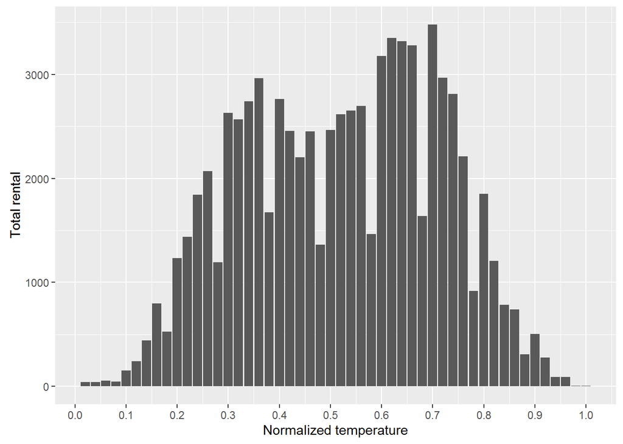

```r
d8%>%
  ggplot(aes(x=temp, y= Total_rental))+
  geom_bar(stat = "identity")+
  scale_x_continuous(breaks=c(seq(from =0, to = 1,by = 0.1)))+
  xlab("Normalized temperature")+
  ylab("Total rental")
```

### Predictor: atemp

Normalized feeling temperature in Celsius. The values are divided to 50 (max)

```r
atemp_Stats <-  c(Mean = mean(d$atemp),
                 Std. = sd(d$atemp),
                 Min. = min(d$atemp),
                 Median = median(d$atemp),
                 Max. = max(d$atemp),
                 Num. = length(d$atemp)
)
print(atemp_Stats)
```

```
##         Mean         Std.         Min.       Median         Max.
## 4.757751e-01 1.718502e-01 0.000000e+00 4.848000e-01 1.000000e+00
##         Num.
## 1.737900e+04
```

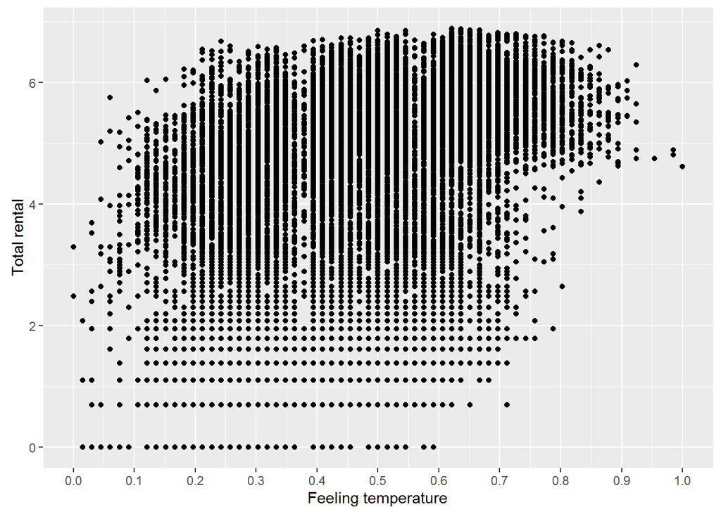

```r
d%>%
ggplot(aes(x=atemp, y= cnt))+
  geom_point()+
  scale_x_continuous(breaks=c(seq(from =0, to = 1,by = 0.1) ))+
  xlab("Feeling temperature")+
  ylab("Total rental")
```

```r
d9 <-
d%>%
  group_by(atemp)%>%
  summarise(Total_rental= sum(cnt))
d9
```

```
## Source: local data frame [65 x 2]
##
##     atemp Total_rental
##     (dbl)        (dbl)
## 1  0.0000     5.780744
## 2  0.0152     3.178054
## 3  0.0303    15.915754
## 4  0.0455    21.546571
## 5  0.0606    39.482407
## 6  0.0758    79.614278
## 7  0.0909    38.532727
## 8  0.1061   129.279288
## 9  0.1212   302.348291
## 10 0.1364   308.671397
## ..    ...          ...
```

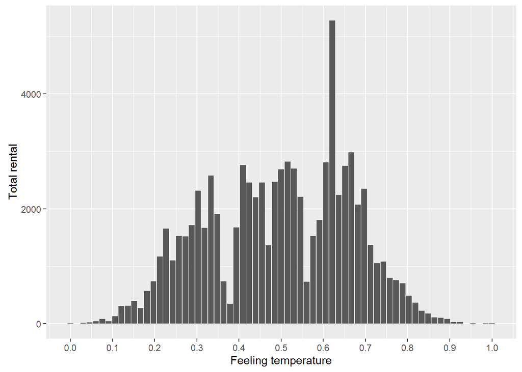

```r
d9%>%
  ggplot(aes(x=atemp, y= Total_rental))+
  geom_bar(stat = "identity")+
  scale_x_continuous(breaks=c(seq(from =0, to = 1,by = 0.1)))+
  xlab("Feeling temperature")+
  ylab("Total rental")
```

### Predictor: humidity

Normalized humidity. The values are divided to 100 (max)

```r
hum_Stats <-  c(Mean = mean(d$hum),
                 Std. = sd(d$hum),
                 Min. = min(d$hum),
                 Median = median(d$hum),
                 Max. = max(d$hum),
                 Num. = length(d$hum)
)
print(hum_Stats)
```

```
##         Mean         Std.         Min.       Median         Max.
## 6.272288e-01 1.929298e-01 0.000000e+00 6.300000e-01 1.000000e+00
##         Num.
## 1.737900e+04
```

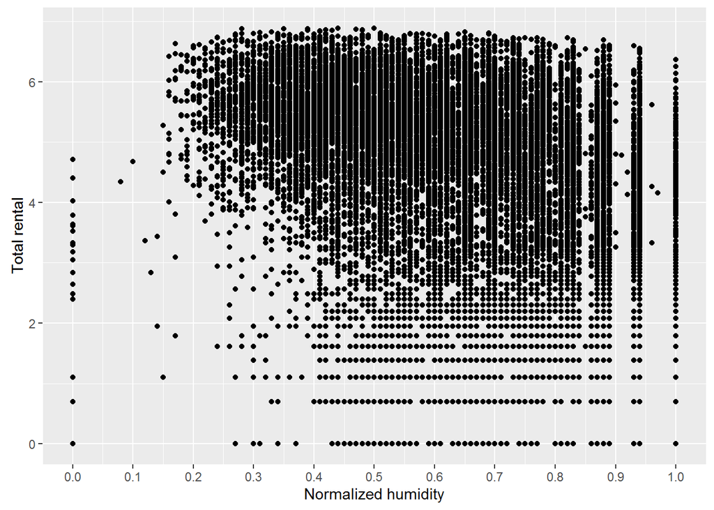

```r
d%>%
ggplot(aes(x=hum, y= cnt))+
  geom_point()+
  scale_x_continuous(breaks=c(seq(from =0, to = 1,by = 0.1) ))+
  xlab("Normalized humidity")+
  ylab("Total rental")
```

```r
d10 <-
d%>%
  group_by(hum)%>%
  summarise(Total_rental= sum(cnt))
d10
```

```
## Source: local data frame [89 x 2]
##
##      hum Total_rental
##    (dbl)        (dbl)
## 1   0.00    62.292891
## 2   0.08     4.343805
## 3   0.10     4.672829
## 4   0.12     3.367296
## 5   0.13     2.833213
## 6   0.14     5.379897
## 7   0.15    11.975149
## 8   0.16    52.493301
## 9   0.17    51.469770
## 10  0.18    56.357652
## ..   ...          ...
```

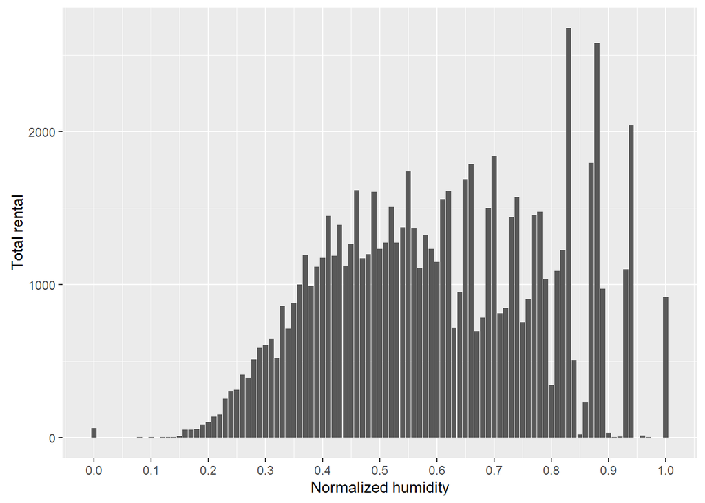

```r
d10%>%
  ggplot(aes(x=hum, y= Total_rental))+
  geom_bar(stat = "identity")+
  scale_x_continuous(breaks=c(seq(from =0, to = 1,by = 0.1)))+
  xlab("Normalized humidity")+
  ylab("Total rental")
```

### Predictor: windspeed

Normalized wind speed. The values are divided to 67 (max)

```r
wind_Stats <-  c(Mean = mean(d$windspeed),
                 Std. = sd(d$windspeed),
                 Min. = min(d$windspeed),
                 Median = median(d$windspeed),
                 Max. = max(d$windspeed),
                 Num. = length(d$windspeed)
)
print(wind_Stats)
```

```
##         Mean         Std.         Min.       Median         Max.
## 1.900976e-01 1.223402e-01 0.000000e+00 1.940000e-01 8.507000e-01
##         Num.
## 1.737900e+04
```

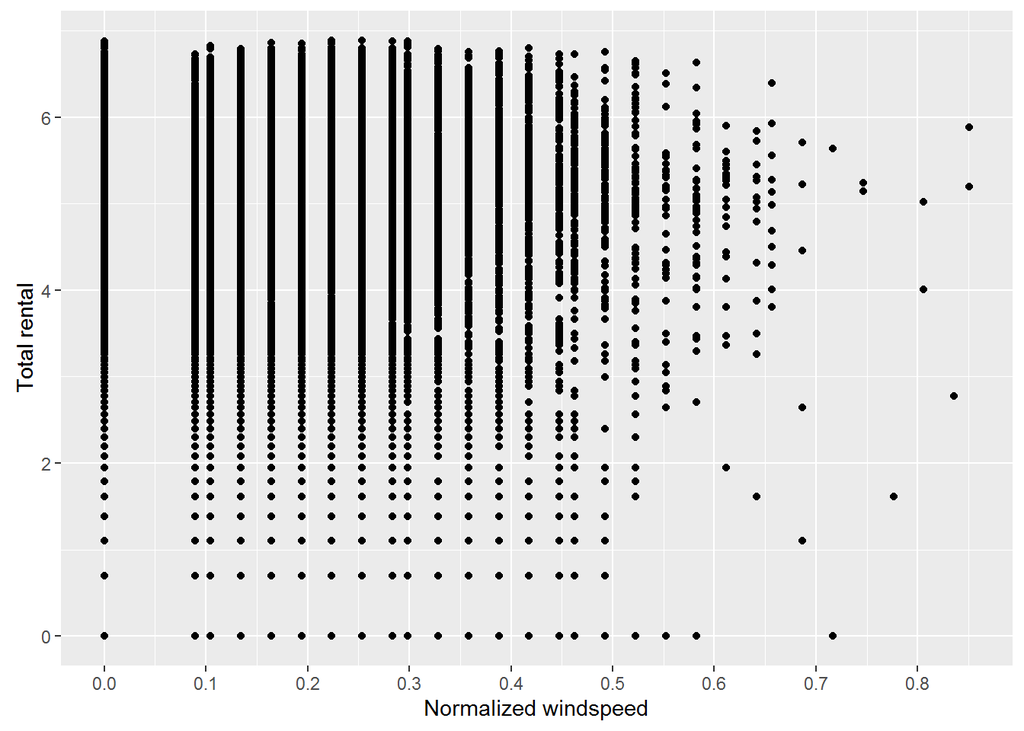

```r
d%>%
ggplot(aes(x=windspeed, y= cnt))+
  geom_point()+
  scale_x_continuous(breaks=c(seq(from =0, to = 1,by = 0.1) ))+
  xlab("Normalized windspeed")+
  ylab("Total rental")
```

```r
d11 <-
d%>%
  group_by(windspeed)%>%
  summarise(Total_rental= sum(cnt))
d11
```

```
## Source: local data frame [30 x 2]
##
##    windspeed Total_rental
##        (dbl)        (dbl)
## 1     0.0000     9300.992
## 2     0.0896     5982.510
## 3     0.1045     7025.344
## 4     0.1343     7663.398
## 5     0.1642     7765.087
## 6     0.1940     7652.837
## 7     0.2239     7120.256
## 8     0.2537     6178.939
## 9     0.2836     4955.381
## 10    0.2985     3809.580
## ..       ...          ...
```

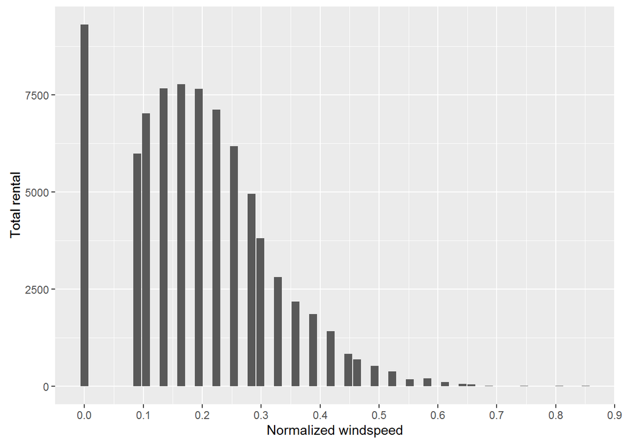

```r
d11%>%
  ggplot(aes(x=windspeed, y= Total_rental))+
  geom_bar(stat = "identity")+
  scale_x_continuous(breaks=c(seq(from =0, to = 1,by = 0.1)))+
  xlab("Normalized windspeed")+
  ylab("Total rental")
```

### Count of casual users

```r
casual_Stats <-  c(Mean = mean(d$casual),
                 Std. = sd(d$casual),
                 Min. = min(d$casual),
                 Median = median(d$casual),
                 Max. = max(d$casual),
                 Num. = length(d$casual)
)
print(casual_Stats)
```

```
##        Mean        Std.        Min.      Median        Max.        Num.
##    35.67622    49.30503     0.00000    17.00000   367.00000 17379.00000
```

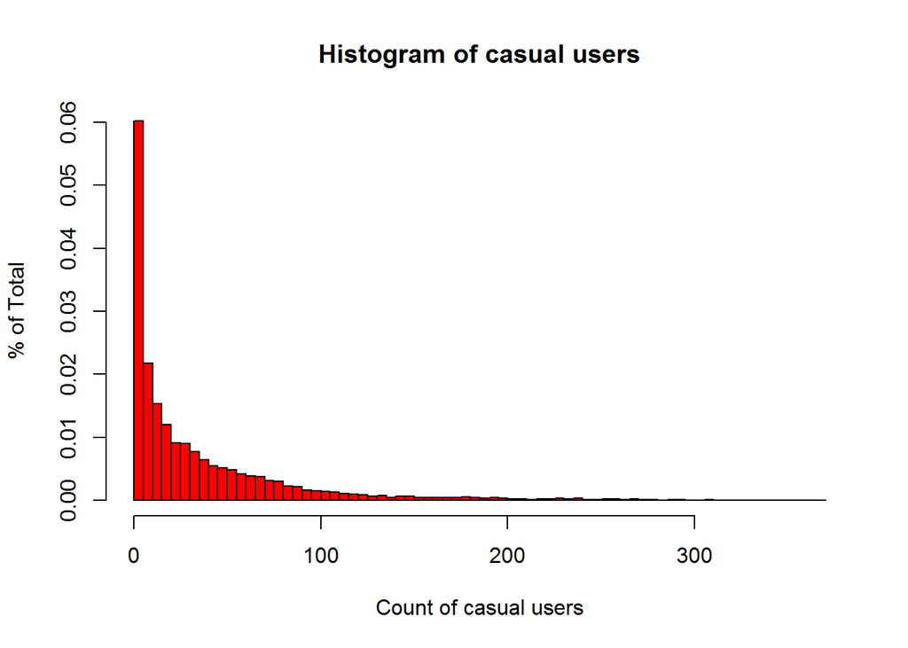

```r
hist(d$casual, freq = F, breaks = 80, col = "red", main = "Histogram of casual users", xlab = "Count of casual users", ylab = "% of Total")
```

### Count of registered users

```r
registered_Stats <-  c(Mean = mean(d$registered),
                 Std. = sd(d$registered),
                 Min. = min(d$registered),
                 Median = median(d$registered),
                 Max. = max(d$registered),
                 Num. = length(d$registered)
)
print(registered_Stats)
```

```
##       Mean       Std.       Min.     Median       Max.       Num.
##   153.7869   151.3573     0.0000   115.0000   886.0000 17379.0000
```

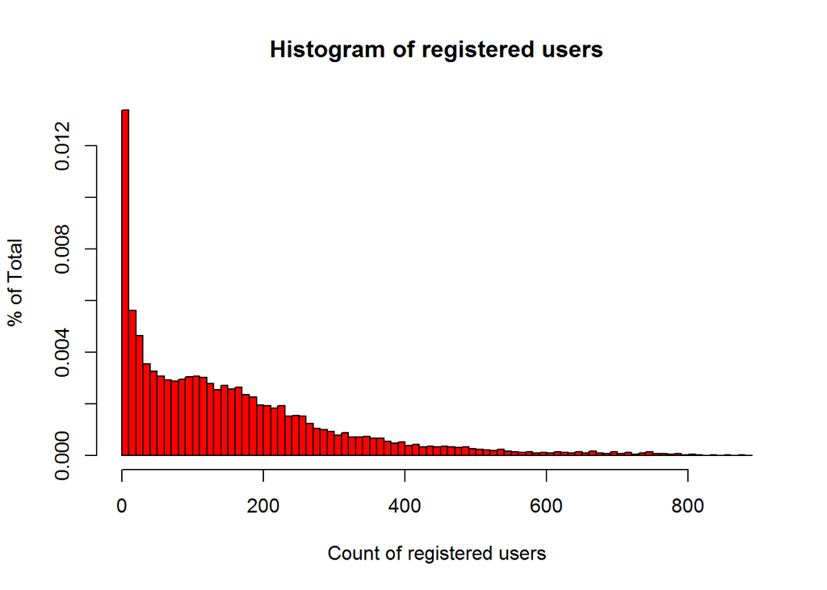

```r
hist(d$registered, freq = F, breaks = 80, col = "red", main = "Histogram of registered users", xlab = "Count of registered users", ylab = "% of Total")
```

### Split train/test (could do CV etc.)

```r
final_data <-
d %>%
select(season, hr, holiday, weekday, workingday, temp, weathersit, atemp, hum, windspeed, cnt)

set.seed(123)
N <- nrow(final_data)
idx_train <- sample(1:N,N/2)
idx_valid <- sample(base::setdiff(1:N, idx_train), N/4)
idx_test <- base::setdiff(base::setdiff(1:N, idx_train),idx_valid)
d_train <- final_data[idx_train,]
d_valid <- final_data[idx_valid,]
d_test  <- final_data[idx_test,]
```

## Summary of explanatory part

As I expected the weather condition is influencing a lot the bike usage, we can see from the graph, in the summer the bike renting is higher than in winter. We can also realize an interesting fact the total renting is quite high between 8-9 am and 5-6 pm this is the time when people are going to work and after going home. When the weather was windy or rainy people used less the bike system.